# NBA

```python
%matplotlib inline
import matplotlib.pyplot as plt
import seaborn as sns

import numpy as np
import pandas as pd
import os

from sklearn.metrics import accuracy_score
from sklearn.cross_validation import train_test_split
from sklearn.ensemble import RandomForestClassifier
```

### The Dataset

The NBA data set I used was scraped and put together using multiple different csv files. The website where I got my data, basketball-reference, had alot of statistics on each team throughout the 2015-2016 season. The question I had throughout this process was predicting which team would win an upcoming game based on their prior stats. I ran into a problem where I had to use seasonal averages rather than game-to-game data.

### Exploring the dataset

Using pandas, I collected all the data together and cleaned the data from around 80 columns for each team to around 50 columns that were relevant to the team rather than their opponents.

```python
stats = pd.read_csv('stats.csv').drop('Unnamed: 0',axis=1)
schedule = pd.read_csv('sched.csv').drop(['Start (ET)','Unnamed: 2','Notes'],axis=1)
schedule = schedule.drop(['Unnamed: 7'],axis=1)
schedule.columns = ['date','team1','points1','team2','points2']
```

```python
stats.head()
```

|  | Rank | Team | GP | MP | FG | FGA | FG% | 3P | 3PA | 3P% | ... | Dist. | 2P_FGA | 0-3 | 3-10 | 10-16 | 16 <3 | 3P_FGA | w_number | l_number | wl_value |
| --- | --- | --- | --- | --- | --- | --- | --- | --- | --- | --- | --- | --- | --- | --- | --- | --- | --- | --- | --- | --- | --- |
| 0 | 1 | Golden State Warriors | 60 | 14550 | 2561 | 5253 | 0.488 | 771 | 1849 | 0.417 | ... | 13.2 | 0.526 | 0.662 | 0.356 | 0.424 | 0.442 | 0.417 | 55 | 5 | 0.917 |
| 1 | 2 | Oklahoma City Thunder | 62 | 15005 | 2552 | 5364 | 0.476 | 503 | 1423 | 0.353 | ... | 11.8 | 0.520 | 0.615 | 0.447 | 0.471 | 0.411 | 0.353 | 42 | 20 | 0.677 |
| 2 | 3 | Sacramento Kings | 61 | 14765 | 2443 | 5276 | 0.463 | 494 | 1379 | 0.358 | ... | 11.6 | 0.500 | 0.644 | 0.396 | 0.418 | 0.393 | 0.358 | 25 | 35 | 0.417 |
| 3 | 4 | Boston Celtics | 64 | 15460 | 2532 | 5743 | 0.441 | 567 | 1702 | 0.333 | ... | 12.5 | 0.486 | 0.621 | 0.347 | 0.391 | 0.392 | 0.333 | 37 | 25 | 0.597 |
| 4 | 5 | Houston Rockets | 62 | 15030 | 2279 | 5130 | 0.444 | 669 | 1942 | 0.344 | ... | 12.6 | 0.505 | 0.646 | 0.334 | 0.386 | 0.372 | 0.344 | 30 | 31 | 0.492 |

5 rows × 56 columns

```python
schedule.head()
```

|  | date | team1 | points1 | team2 | points2 |
| --- | --- | --- | --- | --- | --- |
| 0 | Tue Oct 27 2015 | Detroit Pistons | 106 | Atlanta Hawks | 94 |
| 1 | Tue Oct 27 2015 | Cleveland Cavaliers | 95 | Chicago Bulls | 97 |
| 2 | Tue Oct 27 2015 | New Orleans Pelicans | 95 | Golden State Warriors | 111 |
| 3 | Wed Oct 28 2015 | Philadelphia 76ers | 95 | Boston Celtics | 112 |
| 4 | Wed Oct 28 2015 | Chicago Bulls | 115 | Brooklyn Nets | 100 |

When exploring the data, I chose features that seemed to be relative to what makes a team win a game. I first looked at percentages to see which statistic had a correlation with the number of wins a team has. Some of the plots below show this.

The plot below shows the regression plot between efficient field goal percentage and total number of wins for each team. Turned out to be the most effective regression plot.

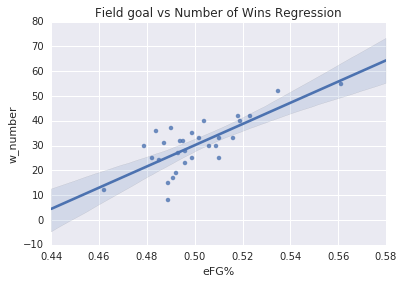

```python
sns.regplot(x='eFG%',y='w_number',data=stats);
plt.title('Field goal vs Number of Wins Regression');
```

The FacetGrid below shows the various distributions of the point spread. Each team has a different center since the center is the mean point spread. Since the team that has a positive difference wins, teams that have a left skewed distribution would have more wins, teams that have a right skewed distribution have more losses than wins, and teams that show a relatively normal distribution will have about a 50% win loss record.

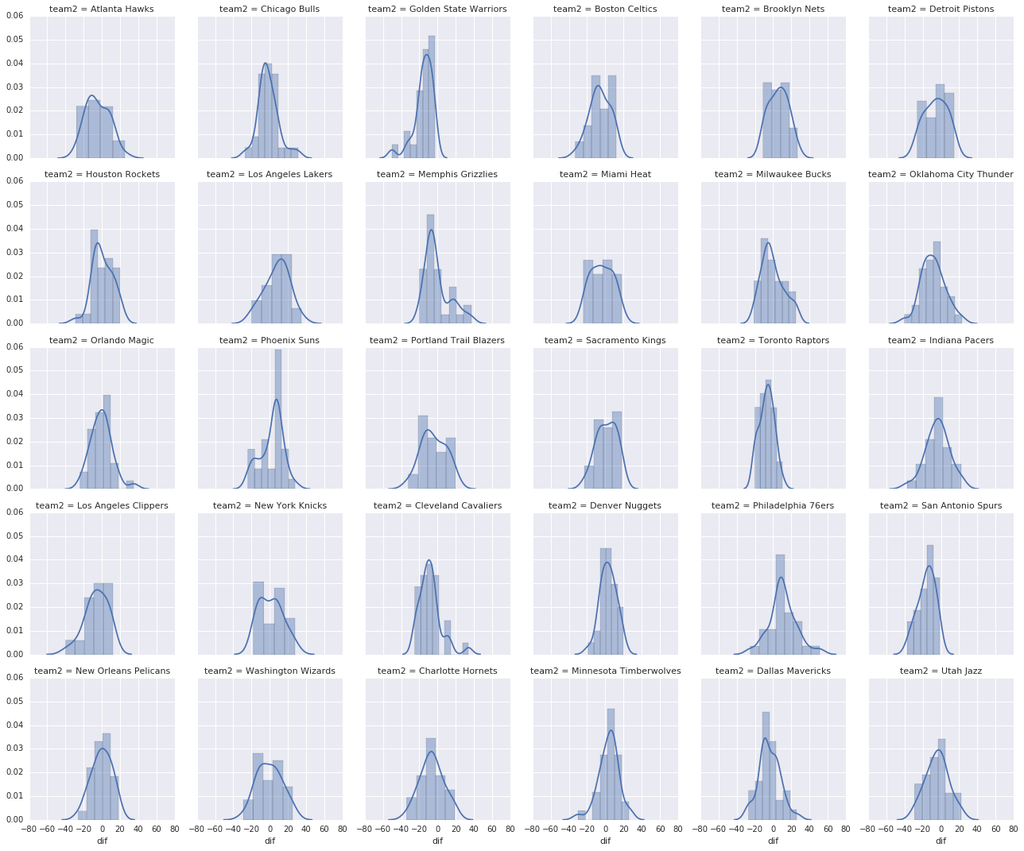

```python
schedule['dif'] = schedule['points1']-schedule['points2']
grid = sns.FacetGrid(schedule, col = 'team2',col_wrap=6);
grid.map(sns.distplot, 'dif');
```

### Machine Learning

**Features**

The features I found useful after exploring more of the data were:

- Efficient Field Goal Percentage
- Turn overs per game
- True Shooting percentage
- Offensive Rating
- Points per game
- Defensive Rating
- Number of wins

target = team2 beats team1

Using these features and the target, I used test_train_split to train my model and RandomForestClassifier to fit my model and create predictions.

```python
teams  = stats[['Team','eFG%','TOV%','TS%','PTS/G','ORtg','DRtg','w_number']]
teams.columns = ['team','field_goals','turn_overs','trueshooting','pointspergame','orating','drating','numwins']
X = pd.merge(teams,schedule,left_on='team',right_on='team2',suffixes=('','_1')).drop('dif',axis=1)
X = pd.merge(teams,X,left_on='team',right_on='team1',suffixes=('_1','_2'))
Xnew = X[X.points1.isnull()]
X =X.dropna()
```

```python
y = X.points1 < X.points2
```

```python
X = X.drop(['team_1','team_2','team1','team2','points1','points2','date'],axis=1)
```

```python
Xtrain, Xtest, ytrain, ytest = train_test_split(X,y,random_state=0)
model = RandomForestClassifier(n_estimators=1000,random_state=0)
model.fit(Xtrain,ytrain)
ypred = model.predict(Xtest)
```

```python
accuracy_score(ypred, ytest)
```

```
0.64377682403433478
```

As you can see above, my model has a 64.37% accuracy, which was the best I could get given the data I had, but it is definitely not the worst since it is still roughlt 15% above random guessing.

Below I created a new column that used my prediction based off the model, to predict a boolean value if team2 beats team1.

```python
Xpred = Xnew[Xnew['points1'].isnull()]
Xnew = Xnew.drop(['date','team_1','team_2','team1','team2','points1','points2'],axis=1)
predict = model.predict(Xnew)
Xpred['prediction(team2 wins)'] = predict
Xpred.head()
```

|  | team_1 | field_goals_1 | turn_overs_1 | trueshooting_1 | pointspergame_1 | orating_1 | drating_1 | numwins_1 | team_2 | field_goals_2 | ... | pointspergame_2 | orating_2 | drating_2 | numwins_2 | date | team1 | points1 | team2 | points2 | prediction(team2 wins) |
| --- | --- | --- | --- | --- | --- | --- | --- | --- | --- | --- | --- | --- | --- | --- | --- | --- | --- | --- | --- | --- | --- |
| 8 | Golden State Warriors | 0.561 | 13.5 | 0.592 | 115.4 | 114.4 | 103.2 | 55 | San Antonio Spurs | 0.535 | ... | 104.7 | 110.8 | 97.6 | 52 | Sat Mar 19 2016 | Golden State Warriors | NaN | San Antonio Spurs | NaN | False |
| 9 | Golden State Warriors | 0.561 | 13.5 | 0.592 | 115.4 | 114.4 | 103.2 | 55 | San Antonio Spurs | 0.535 | ... | 104.7 | 110.8 | 97.6 | 52 | Sun Apr 10 2016 | Golden State Warriors | NaN | San Antonio Spurs | NaN | False |
| 16 | Golden State Warriors | 0.561 | 13.5 | 0.592 | 115.4 | 114.4 | 103.2 | 55 | Dallas Mavericks | 0.502 | ... | 102.5 | 106.6 | 106.6 | 33 | Fri Mar 18 2016 | Golden State Warriors | NaN | Dallas Mavericks | NaN | True |
| 23 | Golden State Warriors | 0.561 | 13.5 | 0.592 | 115.4 | 114.4 | 103.2 | 55 | Minnesota Timberwolves | 0.492 | ... | 101.5 | 106.1 | 110.2 | 19 | Mon Mar 21 2016 | Golden State Warriors | NaN | Minnesota Timberwolves | NaN | False |
| 32 | Golden State Warriors | 0.561 | 13.5 | 0.592 | 115.4 | 114.4 | 103.2 | 55 | Memphis Grizzlies | 0.484 | ... | 99.1 | 105.6 | 105.9 | 36 | Sat Apr 9 2016 | Golden State Warriors | NaN | Memphis Grizzlies | NaN | False |

5 rows × 22 columns

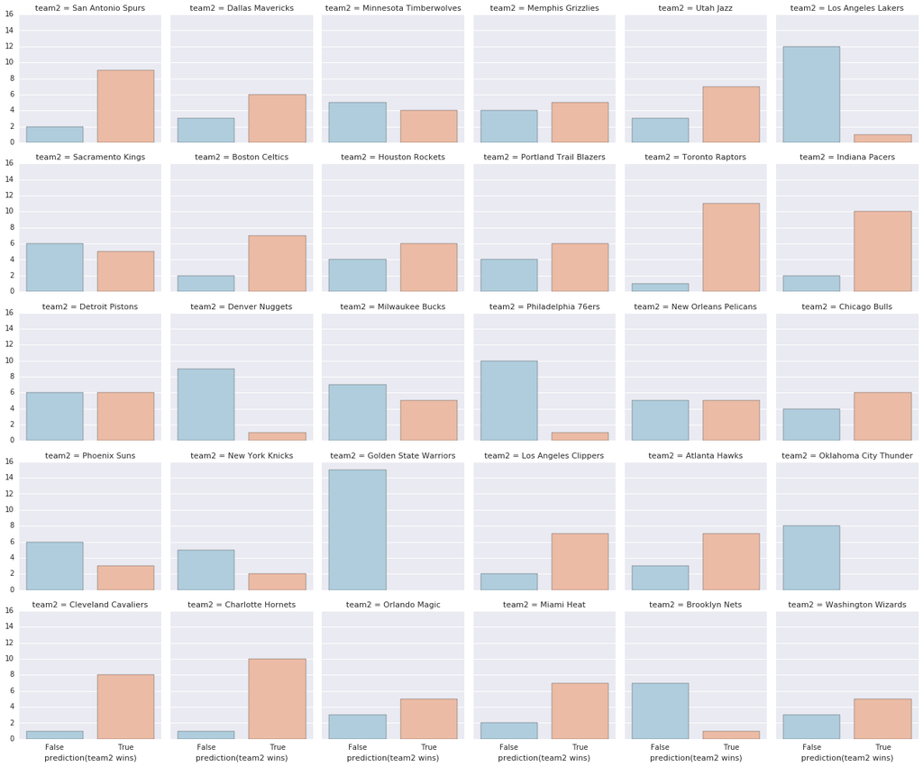

```python
grid = sns.FacetGrid(Xpred, col = 'team2',col_wrap=6)
grid.map(sns.countplot, 'prediction(team2 wins)',palette = sns.color_palette("RdBu_r", n_colors=2))
```